# data_automation_R_HW

2024-10-27

# Чтение данных

В вашем варианте нужно использовать датасет food.

```r
data <- read_csv("data/raw/food.csv")
```

# Выведите общее описание данных

```r
glimpse(data)
```

```
## Rows: 7,083
## Columns: 38
## $ Category                         <chr> "Milk", "Milk", "Milk", "Milk", "Milk…
## $ Description                      <chr> "Milk, human", "Milk, NFS", "Milk, wh…
## $ `Nutrient Data Bank Number`      <dbl> 11000000, 11100000, 11111000, 1111110…
## $ `Data.Alpha Carotene`            <dbl> 0, 0, 0, 0, 0, 0, 0, 0, 0, 0, 0, 0, 0…
## $ `Data.Beta Carotene`             <dbl> 7, 4, 7, 7, 7, 1, 0, 3, 1, 3, 1, 2, 1…
## $ `Data.Beta Cryptoxanthin`        <dbl> 0, 0, 0, 0, 0, 0, 0, 0, 0, 0, 0, 0, 0…
## $ Data.Carbohydrate                <dbl> 6.89, 4.87, 4.67, 4.46, 4.67, 5.19, 4…
## $ Data.Cholesterol                 <dbl> 14, 8, 12, 14, 12, 5, 2, 8, 5, 8, 5, …
## $ Data.Choline                     <dbl> 16.0, 17.9, 17.8, 16.0, 17.8, 17.4, 1…
## $ Data.Fiber                       <dbl> 0, 0, 0, 0, 0, 0, 0, 0, 0, 0, 0, 0, 0…
## $ `Data.Lutein and Zeaxanthin`     <dbl> 0, 0, 0, 0, 0, 0, 0, 0, 0, 0, 0, 0, 0…
## $ Data.Lycopene                    <dbl> 0, 0, 0, 0, 0, 0, 0, 0, 0, 0, 0, 0, 0…
## $ Data.Niacin                      <dbl> 0.177, 0.110, 0.105, 0.043, 0.105, 0.…
```

[output cut: 25 more lines]

# Очистка данных

1. Уберите переменные, в которых пропущенных значений больше 20% или уберите субъектов со слишком большим количеством пропущенных значений. Или совместите оба варианта. Напишите обоснование, почему вы выбрали тот или иной вариант:

2. Переименуйте переменные в человекочитаемый вид (что делать с пробелами в названиях?);
3. В соответствии с описанием данных приведите переменные к нужному типу (numeric или factor);
4. Отсортируйте данные по возрасту по убыванию;
5. Сохраните в файл outliers.csv субъектов, которые являются выбросами (например, по правилу трёх сигм) — это необязательное задание со звёздочкой;
6. Отфильтруйте датасет так, чтобы остались только Rice и Cookie (переменная Category и есть группирующая);
7. Присвойте получившийся датасет переменной “cleaned_data”.

```r
cleaned_data <- data %>% select(where(~ mean(is.na(.)) <= 0.2)) %>%
  filter(rowMeans(is.na(.)) <= 0.2) %>%  # В данном наборе данных отсутствуют пропущенные значения
  rename_with(~ stringi::stri_replace_all_regex
              (., c("\\.", " ", "^Data_", "^Vitamins_", "^Fat_", "^Major_", "-", "__RAE", "Minerals_"),
                c("_", "_", "", "", "", "", "", "", ""),
                vectorize_all = FALSE)) %>%
  mutate(across(where(is.character), as.factor),
         across(where(is.integer), as.numeric),
         Nutrient_Data_Bank_Number =
           as.factor(format(Nutrient_Data_Bank_Number))) %>%
  arrange(desc(`Sugar_Total`)) %>%
  filter(Category == "Rice" | Category == "Cookie") %>%
  mutate(Category = droplevels(Category)) # Убираем лишние уровни фактора


# 5 задание
data %>%
  mutate(across(where(is.numeric),
                ~ (abs(. - mean(., na.rm = TRUE)) > 3 * sd(., na.rm = TRUE)),
                .names = "outlier_{col}")) %>%
  filter(rowSums(select(., starts_with("outlier_"))) > 0) %>%
  select(-starts_with("outlier_")) %>%
  write.csv2(., "outliers.csv", row.names = FALSE)
```

# Сколько осталось переменных?

```r
ncol(cleaned_data)
```

```
## [1] 38
```

# Сколько осталось случаев?

```r
nrow(cleaned_data)
```

```
## [1] 243
```

# Есть ли в данных идентичные строки?

```r
sum(duplicated(cleaned_data))
```

```
## [1] 0
```

# Сколько всего переменных с пропущенными значениями в данных и сколько пропущенных точек в каждой такой переменной?

```r
sum(is.na(cleaned_data))
```

```
## [1] 0
```

# Описательные статистики

## Количественные переменные

1. Рассчитайте для всех количественных переменных для каждой группы (Category):

1.1) Количество значений;

1.2) Количество пропущенных значений;

1.3) Среднее;

1.4) Медиану;

1.5) Стандартное отклонение;

1.6) 25% квантиль и 75% квантиль;

1.7) Интерквартильный размах;

1.8) Минимум;

1.9) Максимум;

1.10) 95% ДИ для среднего - задание со звёздочкой.

```r
statistics <- list(
  `Количество значений` = ~length(.x) %>% as.character(),
  `Количество пропущенных значений` = ~sum(is.na(.x)) %>% as.character(),
  `Среднее` = ~ifelse(sum(!is.na(.x)) == 0, "Н/П*", mean(.x, na.rm = TRUE) %>% round(2) %>% as.character()),
  `Медиана` = ~ifelse(sum(!is.na(.x)) == 0, "Н/П*", median(.x, na.rm = TRUE) %>% round(2) %>% as.character()),
  `Стандартное отклонение` = ~ifelse(sum(!is.na(.x)) == 0, "Н/П*", sd(.x, na.rm = TRUE) %>% round(2) %>% as.character()),
  `25% квантиль` = ~ifelse(sum(!is.na(.x)) == 0, "Н/П*", quantile(.x, 0.25, na.rm = TRUE) %>% round(2) %>% as.character()),
  `75% квантиль` = ~ifelse(sum(!is.na(.x)) == 0, "Н/П*", quantile(.x, 0.75, na.rm = TRUE) %>% round(2) %>% as.character()),
  `Интерквартильный размах` = ~ifelse(sum(!is.na(.x)) == 0, "Н/П*",
                                        IQR(.x, na.rm = TRUE) %>% round(2) %>% as.character()),
  `Минимум` = ~ifelse(sum(!is.na(.x)) == 0, "Н/П*", min(.x, na.rm = TRUE) %>% round(2) %>% as.character()),
  `Максимум` = ~ifelse(sum(!is.na(.x)) == 0, "Н/П*", max(.x, na.rm = TRUE) %>% round(2) %>% as.character()),
  `95% ДИ для среднего` = ~ifelse(sum(!is.na(.x)) == 0, "Н/П*",
                                  {
                                    n = sum(!is.na(.x))
                                    mean_x = mean(.x, na.rm = TRUE)
                                    sd_x = sd(.x, na.rm = TRUE)
                                    error = 1.96 * (sd_x / sqrt(n))
                                    paste0(round(mean_x - error, 2),
                                           " - ",
                                           round(mean_x + error, 2))
                                  })
)

cleaned_data %>%
  select(Category, where(is.numeric)) %>%
  group_by(Category) %>%
  summarise(across(where(is.numeric), statistics, .names = "{.col}&{.fn}")) %>%
  pivot_longer(!Category) %>%
  separate(name, into = c("Variable", "Statistic"), sep = "&") %>%
  rename(Value = value) %>%
  flextable() %>%
  autofit() %>%
  merge_v(j = c("Category", "Variable")) %>%
  hline(j = c("Category", "Variable"), part = "all") %>%
  border(border = fp_border_default(color = "black", width = 1), part = "all")
```

| Category | Variable | Statistic | Value |
| --- | --- | --- | --- |
| Cookie | Alpha_Carotene | Количество значений | 100 |
|  |  | Количество пропущенных значений | 0 |
|  |  | Среднее | 8.25 |
|  |  | Медиана | 0 |
|  |  | Стандартное отклонение | 80.99 |
|  |  | 25% квантиль | 0 |
|  |  | 75% квантиль | 0 |
|  |  | Интерквартильный размах | 0 |
|  |  | Минимум | 0 |
|  |  | Максимум | 810 |
|  |  | 95% ДИ для среднего | -7.62 - 24.12 |
|  | Beta_Carotene | Количество значений | 100 |
|  |  | Количество пропущенных значений | 0 |
|  |  | Среднее | 17.43 |
|  |  | Медиана | 0 |
|  |  | Стандартное отклонение | 102.62 |
|  |  | 25% квантиль | 0 |
|  |  | 75% квантиль | 1 |
|  |  | Интерквартильный размах | 1 |
|  |  | Минимум | 0 |
|  |  | Максимум | 1002 |
|  |  | 95% ДИ для среднего | -2.68 - 37.54 |
|  | Beta_Cryptoxanthin | Количество значений | 100 |
|  |  | Количество пропущенных значений | 0 |
|  |  | Среднее | 0.38 |
|  |  | Медиана | 0 |
|  |  | Стандартное отклонение | 1.98 |
|  |  | 25% квантиль | 0 |
|  |  | 75% квантиль | 0 |
|  |  | Интерквартильный размах | 0 |

[output cut: 740 more lines]

## Категориальные переменные

1. Рассчитайте для всех категориальных переменных для каждой группы (Category):

1.1) Абсолютное количество;

1.2) Относительное количество внутри группы;

1.3) 95% ДИ для доли внутри группы - задание со звёздочкой.

```r
cleaned_data %>%
  group_by(Category) %>%
  summarise(n = n()) %>%
  ungroup() %>%
  mutate(
    Fraction = n / sum(n),  # Доля от общего числа
    CI = map(n, ~prop.test(.x, sum(n), conf.level = 0.95)$conf.int)
  ) %>%
  mutate(
    CI_lower = map_dbl(CI, 1),
    CI_upper = map_dbl(CI, 2)
  ) %>%
  mutate(
    Fraction = round(Fraction, 3),  # Округление до 2 знаков
    CI_lower = round(CI_lower, 3),
    CI_upper = round(CI_upper, 3)) %>%
  select(Category, n, Fraction, CI_lower, CI_upper) %>%
  flextable() %>%
  set_header_labels(n = "Абсолютное количество",
                    Fraction = "Относительное количество внутри группы",
                    CI_lower = "95% ДИ нижний",
                    CI_upper = "95% ДИ верхний") %>%
  autofit() %>%
  border(border = fp_border_default(color = "black", width = 1), part = "all")
```

| Category | Абсолютное количество | Относительное количество внутри группы | 95% ДИ нижний | 95% ДИ верхний |
| --- | --- | --- | --- | --- |
| Cookie | 100 | 0.412 | 0.350 | 0.476 |
| Rice | 143 | 0.588 | 0.524 | 0.650 |

# Визуализация

## Количественные переменные

1. Для каждой количественной переменной сделайте боксплоты по группам. Расположите их либо на отдельных рисунках, либо на одном, но читаемо;
2. Наложите на боксплоты beeplots - задание со звёздочкой.
3. Раскрасьте боксплоты с помощью библиотеки RColorBrewer.

```
## $`1`
```

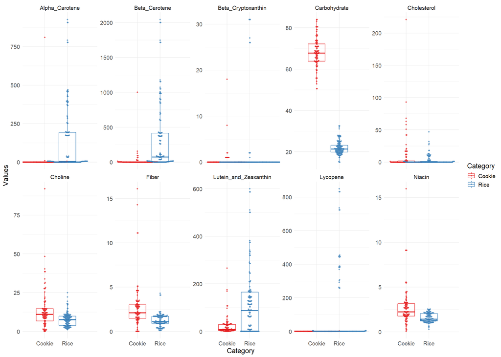

```
##
## $`2`
```

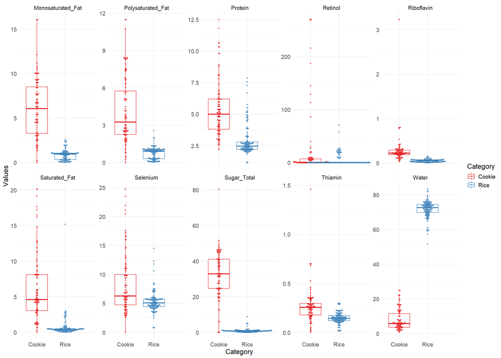

```
##
## $`3`
```

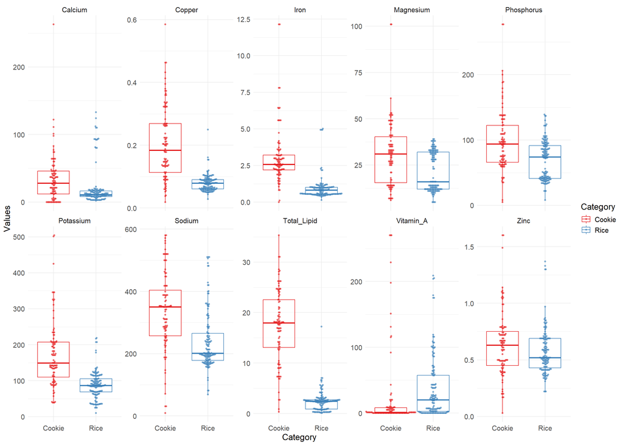

```
##
## $`4`
```

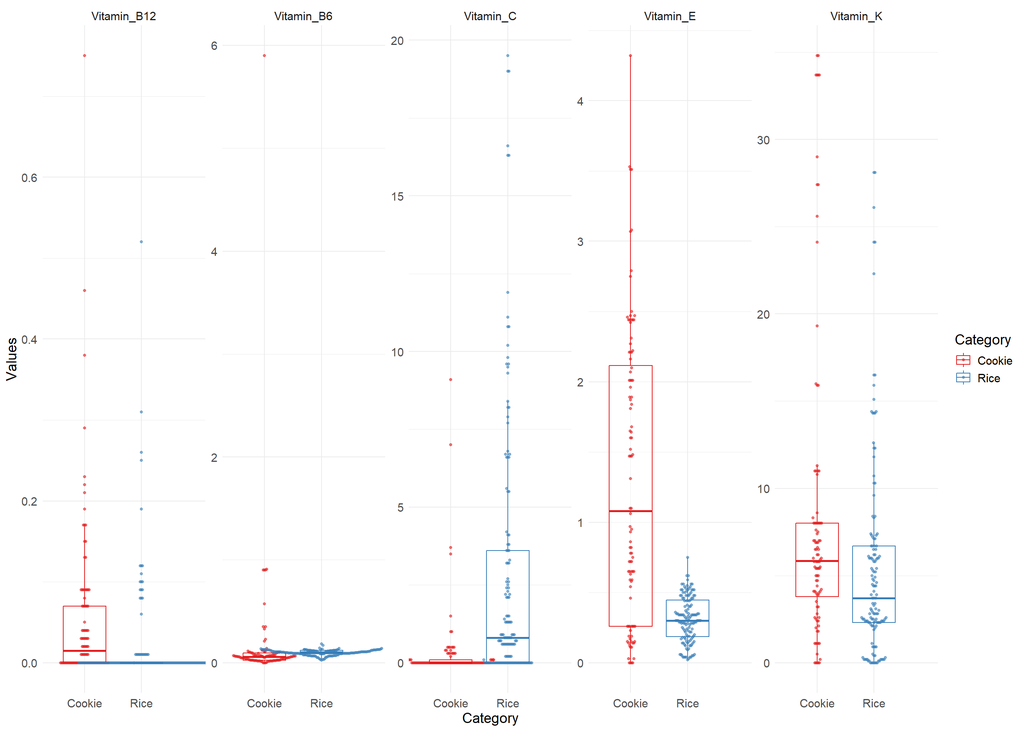

```r
var_groups <- cleaned_data %>%
  select_if(is.numeric) %>%
  names() %>%
  split(ceiling(seq_along(.) / 10)) # Создание групп переменных по 10 в каждой

map(var_groups, function(vars) {
  ggplot(cleaned_data %>%
           select(Category, all_of(vars)) %>%
           pivot_longer(-Category, names_to = "Variable", values_to = "Values"),
         aes(x = Category, y = Values, color = Category)) +
    geom_boxplot(outlier.shape = NA, alpha = 0.5) +
    geom_beeswarm(size = 1, alpha = 0.6) +  # Beeplot
    scale_color_manual(values = brewer.pal(n = 3, name = "Set1")[c(1,2)]) +
    facet_wrap(~Variable, scales = "free_y", ncol = 5) + #RColorBrewer
    theme_minimal() +
    theme(text = element_text(size = 14))
})
```

## Категориальные переменные

1. Сделайте подходящие визуализации категориальных переменных. Обоснуйте, почему выбрали именно этот тип.

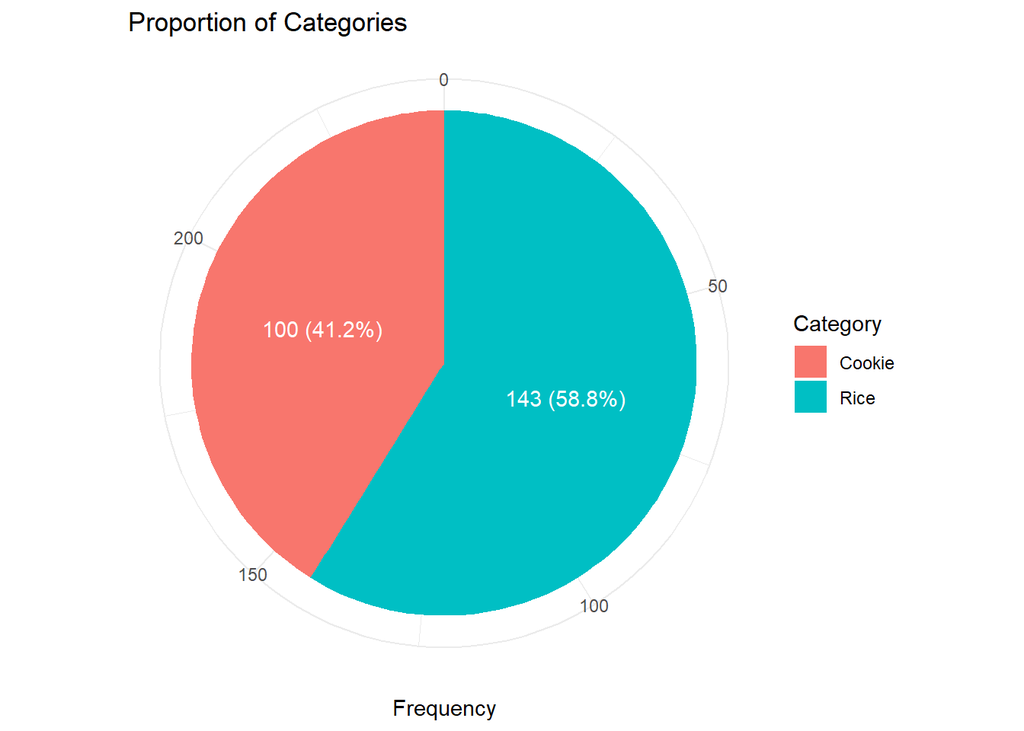

```r
cleaned_data %>%
  group_by(Category) %>%
  summarise(Frequency = n()) %>%
  mutate(Percentage = Frequency / sum(Frequency) * 100) %>%
  ggplot(aes(x = "", y = Frequency, fill = Category)) +
  geom_bar(stat = "identity", width = 1) +
  geom_text(aes(label = paste0(Frequency, " (", round(Percentage, 1), "%)")),
            position = position_stack(vjust = 0.5),
            color = "white") +
  coord_polar("y") +
  labs(title = "Proportion of Categories", fill = "Category", x = NULL) +
  theme_minimal()
```

Сначала выбрал барплот, т.к. это оч распространенный и привычный многим тип графика. Потом решил, что круговая диаграмма нагляднее отражает соотношение.

# Статистические оценки

## Проверка на нормальность

1. Оцените каждую переменную на соответствие нормальному распределению с помощью теста Шапиро-Уилка. Какие из переменных являются нормальными и как как вы это поняли?

```r
cleaned_data %>%
  select(Category, where(is.numeric)) %>%
  group_by(Category) %>%
  summarise(across(where(is.numeric), ~shapiro.test(.x)$p.value %>% round(4))) %>%
  pivot_longer(-Category, names_to = "Variable", values_to = "p_value") %>%
  mutate(`Normal distribution` = ifelse(p_value > 0.05, "Да", "Нет")) %>%
  flextable() %>%
  autofit() %>%
  merge_v(j = c("Category", "Variable")) %>%
  hline(j = c("Category", "Variable"), part = "all") %>%
  border(border = fp_border_default(color = "black", width = 1), part = "all")
```

| Category | Variable | p_value | Normal distribution |
| --- | --- | --- | --- |
| Cookie | Alpha_Carotene | 0.0000 | Нет |
|  | Beta_Carotene | 0.0000 | Нет |
|  | Beta_Cryptoxanthin | 0.0000 | Нет |
|  | Carbohydrate | 0.2023 | Да |
|  | Cholesterol | 0.0000 | Нет |
|  | Choline | 0.0000 | Нет |
|  | Fiber | 0.0000 | Нет |
|  | Lutein_and_Zeaxanthin | 0.0000 | Нет |
|  | Lycopene | 0.0000 | Нет |
|  | Niacin | 0.0000 | Нет |
|  | Protein | 0.0000 | Нет |
|  | Retinol | 0.0000 | Нет |
|  | Riboflavin | 0.0000 | Нет |
|  | Selenium | 0.0000 | Нет |
|  | Sugar_Total | 0.0008 | Нет |
|  | Thiamin | 0.0000 | Нет |
|  | Water | 0.0000 | Нет |
|  | Monosaturated_Fat | 0.0118 | Нет |
|  | Polysaturated_Fat | 0.0000 | Нет |
|  | Saturated_Fat | 0.0000 | Нет |
|  | Total_Lipid | 0.2224 | Да |
|  | Calcium | 0.0000 | Нет |
|  | Copper | 0.0006 | Нет |
|  | Iron | 0.0000 | Нет |
|  | Magnesium | 0.0000 | Нет |
|  | Phosphorus | 0.0000 | Нет |
|  | Potassium | 0.0000 | Нет |
|  | Sodium | 0.0753 | Да |
|  | Zinc | 0.0002 | Нет |
|  | Vitamin_A | 0.0000 | Нет |
|  | Vitamin_B12 | 0.0000 | Нет |
|  | Vitamin_B6 | 0.0000 | Нет |
|  | Vitamin_C | 0.0000 | Нет |
|  | Vitamin_E | 0.0000 | Нет |
|  | Vitamin_K | 0.0000 | Нет |
| Rice | Alpha_Carotene | 0.0000 | Нет |
|  | Beta_Carotene | 0.0000 | Нет |
|  | Beta_Cryptoxanthin | 0.0000 | Нет |
|  | Carbohydrate | 0.0000 | Нет |
|  | Cholesterol | 0.0000 | Нет |
|  | Choline | 0.0000 | Нет |
|  | Fiber | 0.0000 | Нет |
|  | Lutein_and_Zeaxanthin | 0.0000 | Нет |
|  | Lycopene | 0.0000 | Нет |
|  | Niacin | 0.0000 | Нет |
|  | Protein | 0.0000 | Нет |
|  | Retinol | 0.0000 | Нет |
|  | Riboflavin | 0.0000 | Нет |
|  | Selenium | 0.0000 | Нет |
|  | Sugar_Total | 0.0000 | Нет |
|  | Thiamin | 0.0002 | Нет |
|  | Water | 0.0000 | Нет |
|  | Monosaturated_Fat | 0.0000 | Нет |
|  | Polysaturated_Fat | 0.0000 | Нет |
|  | Saturated_Fat | 0.0000 | Нет |
|  | Total_Lipid | 0.0000 | Нет |
|  | Calcium | 0.0000 | Нет |
|  | Copper | 0.0000 | Нет |
|  | Iron | 0.0000 | Нет |
|  | Magnesium | 0.0000 | Нет |
|  | Phosphorus | 0.0000 | Нет |
|  | Potassium | 0.0000 | Нет |
|  | Sodium | 0.0000 | Нет |
|  | Zinc | 0.0000 | Нет |
|  | Vitamin_A | 0.0000 | Нет |
|  | Vitamin_B12 | 0.0000 | Нет |
|  | Vitamin_B6 | 0.0041 | Нет |
|  | Vitamin_C | 0.0000 | Нет |
|  | Vitamin_E | 0.0102 | Нет |
|  | Vitamin_K | 0.0000 | Нет |

Переменные с p-value > 0.05 считаются нормально распределёнными, поскольку не отвергается нулевая гипотеза о нормальном распределении. Нормальное распределение наблюдается по углеводам, жирам и натрию в печенье.

2. Постройте для каждой количественной переменной QQ-плот. Отличаются ли выводы от теста Шапиро-Уилка? Какой метод вы бы предпочли и почему?

```
## $`1`
```

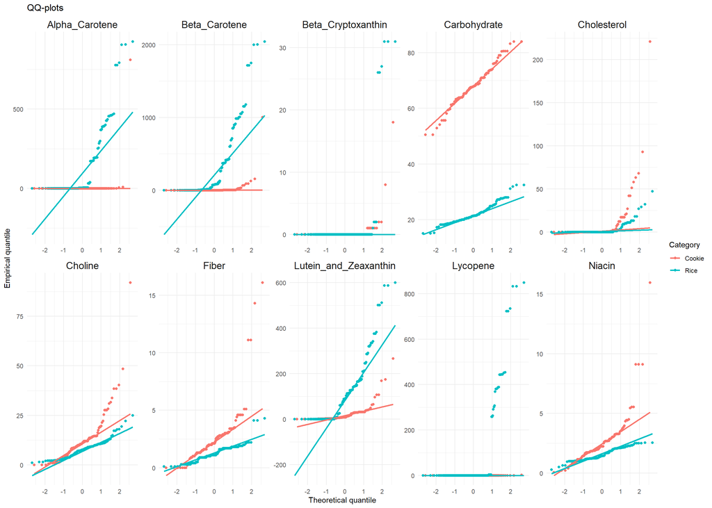

```
##
## $`2`
```

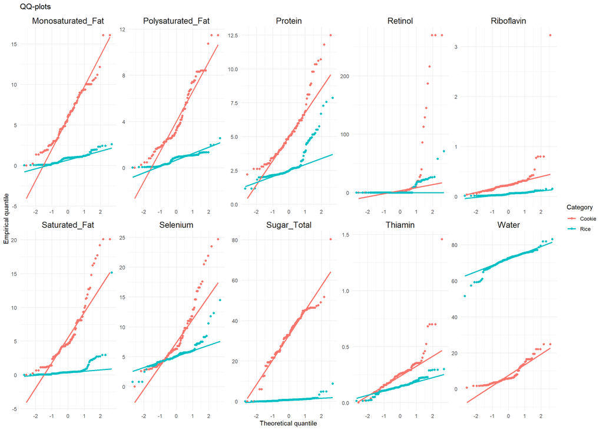

```
##
## $`3`
```

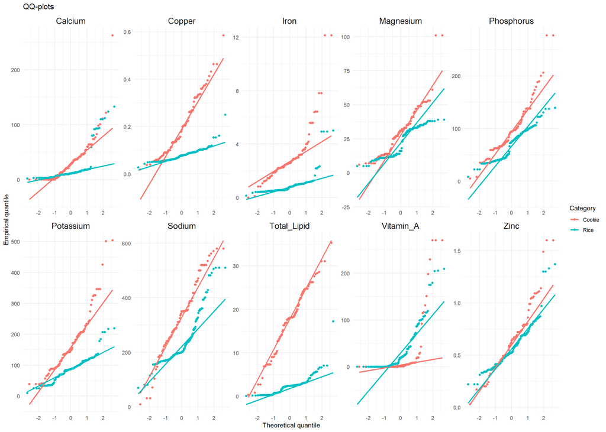

```
##
## $`4`
```

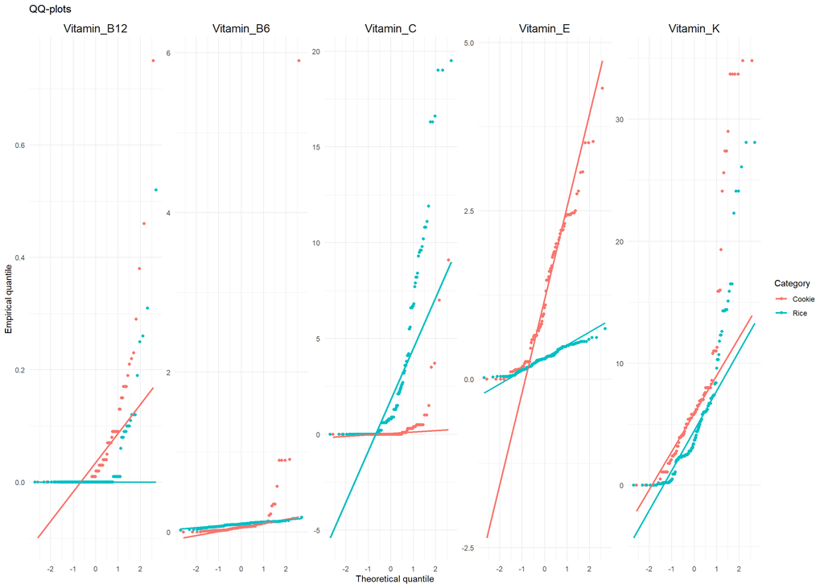

```r
numeric_vars <- cleaned_data %>%
  select(where(is.numeric)) %>%
  names()

# Разюиение на группы по 10 переменных в каждой
var_groups <- split(numeric_vars, ceiling(seq_along(numeric_vars) / 10))

lapply(var_groups, function(vars) {
  cleaned_data %>%
    select(Category, all_of(vars)) %>%
    pivot_longer(-Category, names_to = "Variable", values_to = "Value") %>%
    ggplot(aes(sample = Value, color = Category)) +
    stat_qq() +
    stat_qq_line(size = 1) +
    facet_wrap(~Variable, scales = "free", ncol = 5) +
    labs(
      title = "QQ-plots",
      x = "Theoretical quantile",
      y = "Empirical quantile"
    ) +
    theme_minimal() +
    theme(strip.text = element_text(size = 14))
})
```

Согласно тесту Шапиро-Уилка нормальное распределение наблюдается по переменным Carbohydrate, Total_Lipid, Sodium в группе Cookie. Если смотреть на QQ плоты, по этим переменным данные действительно лежат в пределах линии с оч небольшими отклонениями.

Однако, согласно QQ плотам, я бы сказал, что распределение близко к нормальному также по переменным Fiber и Niacin в группе Rice.

3. Ниже напишите, какие ещё методы проверки на нормальность вы знаете и какие у них есть ограничения.

1.Тест Колмогорова-Смирнова Ограничения: Менее мощный, чем тест Шапиро-Уилка. Может не обнаружить отклонения от нормальности в случае небольших отклонений. Не обладает высокой чувствительностью к отклонениям от нормальности, если данные имеют небольшие выборки. Трудно интерпретировать при большом количестве данных, поскольку его результаты могут быть неточными из-за чувствительности к объему выборки.

2. Тест Лиллиефорса Модификация теста Колмогорова-Смирнова. Ограничения: Это тест, который применяется только к нормальному распределению. Не подходит для данных с другими распределениями. Также чувствителен к выборке и может не сработать на больших объемах данных. Когда использовать: Когда параметры нормального распределения неизвестны и необходимо оценить нормальность без предположений о значениях среднего и дисперсии.
3. Тест Андерсона-Дарлинга Описание: Это более мощный тест, чем тест Колмогорова-Смирнова, и часто используется для проверки нормальности. Он учитывает хвосты распределения, что делает его более чувствительным к отклонениям в этих областях. Ограничения: Как и другие тесты, он может быть чувствителен к большому объему данных и не очень эффективен для малых выборок. Менее известен и реже используется в большинстве стандартных пакетов статистического анализа. Когда использовать: Если необходимо учитывать хвосты распределения (например, при анализе финансовых данных или экстремальных отклонений).
4. Тест Д’Агостино Описание: Этот тест основан на оценке асимметрии (скоса) и эксцесса (крутоты) распределения и проверяет гипотезу о нормальности распределения. Он используется для больших выборок. Ограничения: Применим для больших выборок, так как он может быть неточным для малых выборок. Может не справляться с отклонениями от нормальности, которые выражены в хвостах распределения, так как фокусируется на центральной части распределения. Когда использовать: Для больших выборок, особенно когда необходимо учитывать асимметрию и эксцесс.

## Сравнение групп

1. Сравните группы (переменная **Category**) по каждой переменной (как количественной, так и категориальной). Для каждой переменной выберите нужный критерий и кратко обоснуйте его выбор в комментариях.

```r
# С учетом распределения данных и наличия двух групп данных был выбран тест Манна-Уитни
cleaned_data %>%
  select(Category, where(is.numeric)) %>%
  pivot_longer(-Category, names_to = "Variable", values_to = "Value") %>%
  group_by(Variable) %>%
  summarise(
    test_result = list(wilcox.test(Value ~ Category)),
    p_value = test_result[[1]]$p.value) %>%
  mutate(
    p_value = ifelse(p_value < 0.001, "<0,001", round(p_value, 3)),  # Форматирование p-значений
    significance = ifelse(p_value < 0.05, "Yes", "No")  # Определение значимости
  ) %>%
  select(Variable, p_value, significance) %>%
  flextable()
```

| Variable | p_value | significance |
| --- | --- | --- |
| Alpha_Carotene | <0,001 | Yes |
| Beta_Carotene | <0,001 | Yes |
| Beta_Cryptoxanthin | 0.241 | No |
| Calcium | <0,001 | Yes |
| Carbohydrate | <0,001 | Yes |
| Cholesterol | 0.316 | No |
| Choline | <0,001 | Yes |
| Copper | <0,001 | Yes |
| Fiber | <0,001 | Yes |
| Iron | <0,001 | Yes |
| Lutein_and_Zeaxanthin | <0,001 | Yes |
| Lycopene | <0,001 | Yes |
| Magnesium | <0,001 | Yes |
| Monosaturated_Fat | <0,001 | Yes |
| Niacin | <0,001 | Yes |
| Phosphorus | <0,001 | Yes |
| Polysaturated_Fat | <0,001 | Yes |
| Potassium | <0,001 | Yes |
| Protein | <0,001 | Yes |
| Retinol | <0,001 | Yes |
| Riboflavin | <0,001 | Yes |
| Saturated_Fat | <0,001 | Yes |
| Selenium | <0,001 | Yes |
| Sodium | <0,001 | Yes |
| Sugar_Total | <0,001 | Yes |
| Thiamin | <0,001 | Yes |
| Total_Lipid | <0,001 | Yes |
| Vitamin_A | <0,001 | Yes |
| Vitamin_B12 | <0,001 | Yes |
| Vitamin_B6 | <0,001 | Yes |
| Vitamin_C | <0,001 | Yes |
| Vitamin_E | <0,001 | Yes |
| Vitamin_K | <0,001 | Yes |
| Water | <0,001 | Yes |
| Zinc | 0.085 | No |

# Далее идут **необязательные** дополнительные задания, которые могут принести вам дополнительные баллы в том числе в случае ошибок в предыдущих

## Корреляционный анализ

1. Создайте корреляционную матрицу с визуализацией и поправкой на множественные сравнения. Объясните, когда лучше использовать корреляционные матрицы и в чём минусы и плюсы корреляционных исследований.

```r
cleaned_data %>%
  select_if(is.numeric) %>%
  as.matrix() %>%
  rcorr() %>%
    {
      cor_matr <- .$r
      p_val <- .$P
      p_val_adj <- p.adjust(as.vector(p_val), method = "bonferroni")

      map2(cor_matr, p_val_adj, ~paste0("r = ", round(.x, 2), "\np = ", round(.y, 3))) %>%
        flatten_chr() %>%
        matrix(nrow = nrow(cor_matr), ncol = ncol(cor_matr),
               dimnames = list(colnames(cor_matr), colnames(cor_matr))) %>%
        as.data.frame() %>%
        rownames_to_column(var = "Variable")
    } %>%
        flextable() %>%
        autofit() %>%
        border(border = fp_border_default(color = "black", width = 1), part = "all")
```

| Variable | Alpha_Carotene | Beta_Carotene | Beta_Cryptoxanthin | Carbohydrate | Cholesterol | Choline | Fiber | Lutein_and_Zeaxanthin | Lycopene | Niacin | Protein | Retinol | Riboflavin | Selenium | Sugar_Total | Thiamin | Water | Monosaturated_Fat | Polysaturated_Fat | Saturated_Fat | Total_Lipid | Calcium | Copper | Iron | Magnesium | Phosphorus | Potassium | Sodium | Zinc | … |
| --- | --- | --- | --- | --- | --- | --- | --- | --- | --- | --- | --- | --- | --- | --- | --- | --- | --- | --- | --- | --- | --- | --- | --- | --- | --- | --- | --- | --- | --- | --- |
| Alpha_Carotene | r = 1 p = NA | r = 0.98 p = 0 | r = -0.07 p = 1 | r = -0.32 p = 0 | r = -0.09 p = 1 | r = -0.12 p = 1 | r = -0.08 p = 1 | r = 0.38 p = 0 | r = 0.09 p = 1 | r = -0.1 p = 1 | r = -0.25 p = 0.101 | r = -0.11 p = 1 | r = -0.14 p = 1 | r = -0.08 p = 1 | r = -0.29 p = 0.004 | r = -0.1 p = 1 | r = 0.33 p = 0 | r = -0.26 p = 0.037 | r = -0.22 p = 0.5 | r = -0.25 p = 0.114 | r = -0.3 p = 0.003 | r = -0.07 p = 1 | r = -0.26 p = 0.061 | r = -0.23 p = 0.336 | r = -0.11 p = 1 | r = -0.12 p = 1 | r = -0.07 p = 1 | r = -0.29 p = 0.004 | r = -0.12 p = 1 | … |
| Beta_Carotene | r = 0.98 p = 0 | r = 1 p = NA | r = -0.08 p = 1 | r = -0.37 p = 0 | r = -0.09 p = 1 | r = -0.11 p = 1 | r = -0.09 p = 1 | r = 0.48 p = 0 | r = 0.12 p = 1 | r = -0.13 p = 1 | r = -0.28 p = 0.011 | r = -0.1 p = 1 | r = -0.17 p = 1 | r = -0.11 p = 1 | r = -0.33 p = 0 | r = -0.11 p = 1 | r = 0.38 p = 0 | r = -0.3 p = 0.002 | r = -0.26 p = 0.056 | r = -0.27 p = 0.019 | r = -0.33 p = 0 | r = -0.1 p = 1 | r = -0.27 p = 0.021 | r = -0.26 p = 0.039 | r = -0.12 p = 1 | r = -0.16 p = 1 | r = -0.12 p = 1 | r = -0.31 p = 0.001 | r = -0.13 p = 1 | … |
| Beta_Cryptoxanthin | r = -0.07 p = 1 | r = -0.08 p = 1 | r = 1 p = NA | r = -0.07 p = 1 | r = 0.06 p = 1 | r = 0.08 p = 1 | r = -0.03 p = 1 | r = 0.12 p = 1 | r = -0.06 p = 1 | r = -0.01 p = 1 | r = -0.05 p = 1 | r = -0.03 p = 1 | r = -0.05 p = 1 | r = -0.02 p = 1 | r = -0.09 p = 1 | r = -0.03 p = 1 | r = 0.08 p = 1 | r = -0.07 p = 1 | r = -0.05 p = 1 | r = -0.09 p = 1 | r = -0.09 p = 1 | r = -0.07 p = 1 | r = -0.08 p = 1 | r = -0.06 p = 1 | r = -0.02 p = 1 | r = 0.01 p = 1 | r = -0.02 p = 1 | r = -0.16 p = 1 | r = 0.01 p = 1 | … |
| Carbohydrate | r = -0.32 p = 0 | r = -0.37 p = 0 | r = -0.07 p = 1 | r = 1 p = NA | r = 0.13 p = 1 | r = 0.25 p = 0.086 | r = 0.34 p = 0 | r = -0.38 p = 0 | r = -0.27 p = 0.018 | r = 0.4 p = 0 | r = 0.58 p = 0 | r = 0.22 p = 0.859 | r = 0.47 p = 0 | r = 0.37 p = 0 | r = 0.88 p = 0 | r = 0.45 p = 0 | r = -0.98 p = 0 | r = 0.71 p = 0 | r = 0.62 p = 0 | r = 0.57 p = 0 | r = 0.75 p = 0 | r = 0.21 p = 1 | r = 0.59 p = 0 | r = 0.6 p = 0 | r = 0.28 p = 0.014 | r = 0.32 p = 0 | r = 0.52 p = 0 | r = 0.4 p = 0 | r = 0.1 p = 1 | … |
| Cholesterol | r = -0.09 p = 1 | r = -0.09 p = 1 | r = 0.06 p = 1 | r = 0.13 p = 1 | r = 1 p = NA | r = 0.69 p = 0 | r = -0.04 p = 1 | r = 0.02 p = 1 | r = -0.08 p = 1 | r = 0.02 p = 1 | r = 0.37 p = 0 | r = 0.28 p = 0.008 | r = 0.13 p = 1 | r = 0.42 p = 0 | r = 0.13 p = 1 | r = 0.04 p = 1 | r = -0.16 p = 1 | r = 0.13 p = 1 | r = 0.09 p = 1 | r = 0.1 p = 1 | r = 0.14 p = 1 | r = 0.19 p = 1 | r = 0.02 p = 1 | r = 0.04 p = 1 | r = -0.08 p = 1 | r = 0.24 p = 0.237 | r = 0.02 p = 1 | r = 0 p = 1 | r = 0.19 p = 1 | … |
| Choline | r = -0.12 p = 1 | r = -0.11 p = 1 | r = 0.08 p = 1 | r = 0.25 p = 0.086 | r = 0.69 p = 0 | r = 1 p = NA | r = 0.17 p = 1 | r = 0.07 p = 1 | r = -0.13 p = 1 | r = 0.16 p = 1 | r = 0.58 p = 0 | r = 0.11 p = 1 | r = 0.24 p = 0.193 | r = 0.52 p = 0 | r = 0.24 p = 0.259 | r = 0.12 p = 1 | r = -0.29 p = 0.004 | r = 0.23 p = 0.34 | r = 0.18 p = 1 | r = 0.18 p = 1 | r = 0.25 p = 0.133 | r = 0.3 p = 0.003 | r = 0.26 p = 0.059 | r = 0.18 p = 1 | r = 0.35 p = 0 | r = 0.55 p = 0 | r = 0.41 p = 0 | r = 0.06 p = 1 | r = 0.47 p = 0 | … |
| Fiber | r = -0.08 p = 1 | r = -0.09 p = 1 | r = -0.03 p = 1 | r = 0.34 p = 0 | r = -0.04 p = 1 | r = 0.17 p = 1 | r = 1 p = NA | r = -0.09 p = 1 | r = -0.09 p = 1 | r = -0.03 p = 1 | r = 0.14 p = 1 | r = -0.08 p = 1 | r = 0.06 p = 1 | r = 0.24 p = 0.194 | r = 0.33 p = 0 | r = 0.01 p = 1 | r = -0.35 p = 0 | r = 0.3 p = 0.002 | r = 0.3 p = 0.002 | r = 0.27 p = 0.025 | r = 0.34 p = 0 | r = -0.04 p = 1 | r = 0.3 p = 0.002 | r = 0.17 p = 1 | r = 0.29 p = 0.005 | r = 0.2 p = 1 | r = 0.33 p = 0 | r = 0.11 p = 1 | r = 0.12 p = 1 | … |
| Lutein_and_Zeaxanthin | r = 0.38 p = 0 | r = 0.48 p = 0 | r = 0.12 p = 1 | r = -0.38 p = 0 | r = 0.02 p = 1 | r = 0.07 p = 1 | r = -0.09 p = 1 | r = 1 p = NA | r = 0.03 p = 1 | r = -0.13 p = 1 | r = -0.18 p = 1 | r = -0.13 p = 1 | r = -0.18 p = 1 | r = -0.03 p = 1 | r = -0.37 p = 0 | r = -0.12 p = 1 | r = 0.39 p = 0 | r = -0.33 p = 0 | r = -0.28 p = 0.008 | r = -0.3 p = 0.002 | r = -0.37 p = 0 | r = -0.09 p = 1 | r = -0.28 p = 0.015 | r = -0.27 p = 0.017 | r = -0.09 p = 1 | r = -0.09 p = 1 | r = -0.16 p = 1 | r = -0.36 p = 0 | r = -0.01 p = 1 | … |
| Lycopene | r = 0.09 p = 1 | r = 0.12 p = 1 | r = -0.06 p = 1 | r = -0.27 p = 0.018 | r = -0.08 p = 1 | r = -0.13 p = 1 | r = -0.09 p = 1 | r = 0.03 p = 1 | r = 1 p = NA | r = -0.09 p = 1 | r = -0.25 p = 0.078 | r = -0.09 p = 1 | r = -0.13 p = 1 | r = -0.12 p = 1 | r = -0.23 p = 0.405 | r = 0.11 p = 1 | r = 0.28 p = 0.008 | r = -0.21 p = 1 | r = -0.18 p = 1 | r = -0.19 p = 1 | r = -0.24 p = 0.23 | r = -0.1 p = 1 | r = -0.17 p = 1 | r = -0.18 p = 1 | r = -0.1 p = 1 | r = -0.18 p = 1 | r = -0.08 p = 1 | r = -0.24 p = 0.151 | r = -0.17 p = 1 | … |
| Niacin | r = -0.1 p = 1 | r = -0.13 p = 1 | r = -0.01 p = 1 | r = 0.4 p = 0 | r = 0.02 p = 1 | r = 0.16 p = 1 | r = -0.03 p = 1 | r = -0.13 p = 1 | r = -0.09 p = 1 | r = 1 p = NA | r = 0.44 p = 0 | r = 0.39 p = 0 | r = 0.85 p = 0 | r = 0.31 p = 0.001 | r = 0.15 p = 1 | r = 0.87 p = 0 | r = -0.4 p = 0 | r = 0.26 p = 0.04 | r = 0.39 p = 0 | r = 0.12 p = 1 | r = 0.28 p = 0.008 | r = 0.13 p = 1 | r = 0.18 p = 1 | r = 0.28 p = 0.012 | r = 0.25 p = 0.134 | r = 0.3 p = 0.002 | r = 0.36 p = 0 | r = 0.18 p = 1 | r = 0.19 p = 1 | … |
| Protein | r = -0.25 p = 0.101 | r = -0.28 p = 0.011 | r = -0.05 p = 1 | r = 0.58 p = 0 | r = 0.37 p = 0 | r = 0.58 p = 0 | r = 0.14 p = 1 | r = -0.18 p = 1 | r = -0.25 p = 0.078 | r = 0.44 p = 0 | r = 1 p = NA | r = 0.07 p = 1 | r = 0.46 p = 0 | r = 0.54 p = 0 | r = 0.37 p = 0 | r = 0.36 p = 0 | r = -0.64 p = 0 | r = 0.49 p = 0 | r = 0.42 p = 0 | r = 0.38 p = 0 | r = 0.52 p = 0 | r = 0.46 p = 0 | r = 0.44 p = 0 | r = 0.39 p = 0 | r = 0.41 p = 0 | r = 0.67 p = 0 | r = 0.62 p = 0 | r = 0.33 p = 0 | r = 0.57 p = 0 | … |
| Retinol | r = -0.11 p = 1 | r = -0.1 p = 1 | r = -0.03 p = 1 | r = 0.22 p = 0.859 | r = 0.28 p = 0.008 | r = 0.11 p = 1 | r = -0.08 p = 1 | r = -0.13 p = 1 | r = -0.09 p = 1 | r = 0.39 p = 0 | r = 0.07 p = 1 | r = 1 p = NA | r = 0.29 p = 0.005 | r = 0.27 p = 0.028 | r = 0.14 p = 1 | r = 0.33 p = 0 | r = -0.19 p = 1 | r = 0.1 p = 1 | r = 0.19 p = 1 | r = 0.05 p = 1 | r = 0.11 p = 1 | r = 0.12 p = 1 | r = -0.01 p = 1 | r = 0.02 p = 1 | r = -0.12 p = 1 | r = -0.02 p = 1 | r = -0.08 p = 1 | r = 0.12 p = 1 | r = -0.02 p = 1 | … |
| Riboflavin | r = -0.14 p = 1 | r = -0.17 p = 1 | r = -0.05 p = 1 | r = 0.47 p = 0 | r = 0.13 p = 1 | r = 0.24 p = 0.193 | r = 0.06 p = 1 | r = -0.18 p = 1 | r = -0.13 p = 1 | r = 0.85 p = 0 | r = 0.46 p = 0 | r = 0.29 p = 0.005 | r = 1 p = NA | r = 0.37 p = 0 | r = 0.34 p = 0 | r = 0.84 p = 0 | r = -0.47 p = 0 | r = 0.32 p = 0 | r = 0.32 p = 0 | r = 0.19 p = 1 | r = 0.32 p = 0 | r = 0.28 p = 0.012 | r = 0.19 p = 1 | r = 0.32 p = 0 | r = 0.2 p = 1 | r = 0.31 p = 0.001 | r = 0.46 p = 0 | r = 0.19 p = 1 | r = 0.21 p = 1 | … |
| Selenium | r = -0.08 p = 1 | r = -0.11 p = 1 | r = -0.02 p = 1 | r = 0.37 p = 0 | r = 0.42 p = 0 | r = 0.52 p = 0 | r = 0.24 p = 0.194 | r = -0.03 p = 1 | r = -0.12 p = 1 | r = 0.31 p = 0.001 | r = 0.54 p = 0 | r = 0.27 p = 0.028 | r = 0.37 p = 0 | r = 1 p = NA | r = 0.22 p = 0.718 | r = 0.35 p = 0 | r = -0.38 p = 0 | r = 0.21 p = 1 | r = 0.22 p = 0.509 | r = 0.25 p = 0.11 | r = 0.28 p = 0.012 | r = 0.27 p = 0.025 | r = 0.07 p = 1 | r = 0.13 p = 1 | r = 0.1 p = 1 | r = 0.36 p = 0 | r = 0.3 p = 0.002 | r = 0.21 p = 1 | r = 0.25 p = 0.109 | … |
| Sugar_Total | r = -0.29 p = 0.004 | r = -0.33 p = 0 | r = -0.09 p = 1 | r = 0.88 p = 0 | r = 0.13 p = 1 | r = 0.24 p = 0.259 | r = 0.33 p = 0 | r = -0.37 p = 0 | r = -0.23 p = 0.405 | r = 0.15 p = 1 | r = 0.37 p = 0 | r = 0.14 p = 1 | r = 0.34 p = 0 | r = 0.22 p = 0.718 | r = 1 p = NA | r = 0.24 p = 0.242 | r = -0.87 p = 0 | r = 0.67 p = 0 | r = 0.49 p = 0 | r = 0.61 p = 0 | r = 0.71 p = 0 | r = 0.16 p = 1 | r = 0.6 p = 0 | r = 0.52 p = 0 | r = 0.25 p = 0.092 | r = 0.22 p = 0.611 | r = 0.45 p = 0 | r = 0.29 p = 0.004 | r = 0.04 p = 1 | … |
| Thiamin | r = -0.1 p = 1 | r = -0.11 p = 1 | r = -0.03 p = 1 | r = 0.45 p = 0 | r = 0.04 p = 1 | r = 0.12 p = 1 | r = 0.01 p = 1 | r = -0.12 p = 1 | r = 0.11 p = 1 | r = 0.87 p = 0 | r = 0.36 p = 0 | r = 0.33 p = 0 | r = 0.84 p = 0 | r = 0.35 p = 0 | r = 0.24 p = 0.242 | r = 1 p = NA | r = -0.45 p = 0 | r = 0.31 p = 0.001 | r = 0.44 p = 0 | r = 0.17 p = 1 | r = 0.34 p = 0 | r = 0.14 p = 1 | r = 0.17 p = 1 | r = 0.3 p = 0.003 | r = 0.18 p = 1 | r = 0.29 p = 0.003 | r = 0.38 p = 0 | r = 0.17 p = 1 | r = 0.1 p = 1 | … |
| Water | r = 0.33 p = 0 | r = 0.38 p = 0 | r = 0.08 p = 1 | r = -0.98 p = 0 | r = -0.16 p = 1 | r = -0.29 p = 0.004 | r = -0.35 p = 0 | r = 0.39 p = 0 | r = 0.28 p = 0.008 | r = -0.4 p = 0 | r = -0.64 p = 0 | r = -0.19 p = 1 | r = -0.47 p = 0 | r = -0.38 p = 0 | r = -0.87 p = 0 | r = -0.45 p = 0 | r = 1 p = NA | r = -0.79 p = 0 | r = -0.71 p = 0 | r = -0.68 p = 0 | r = -0.86 p = 0 | r = -0.23 p = 0.455 | r = -0.65 p = 0 | r = -0.62 p = 0 | r = -0.33 p = 0 | r = -0.38 p = 0 | r = -0.54 p = 0 | r = -0.42 p = 0 | r = -0.17 p = 1 | … |
| Monosaturated_Fat | r = -0.26 p = 0.037 | r = -0.3 p = 0.002 | r = -0.07 p = 1 | r = 0.71 p = 0 | r = 0.13 p = 1 | r = 0.23 p = 0.34 | r = 0.3 p = 0.002 | r = -0.33 p = 0 | r = -0.21 p = 1 | r = 0.26 p = 0.04 | r = 0.49 p = 0 | r = 0.1 p = 1 | r = 0.32 p = 0 | r = 0.21 p = 1 | r = 0.67 p = 0 | r = 0.31 p = 0.001 | r = -0.79 p = 0 | r = 1 p = NA | r = 0.64 p = 0 | r = 0.5 p = 0 | r = 0.84 p = 0 | r = 0.2 p = 1 | r = 0.55 p = 0 | r = 0.62 p = 0 | r = 0.3 p = 0.002 | r = 0.37 p = 0 | r = 0.38 p = 0 | r = 0.43 p = 0 | r = 0.19 p = 1 | … |
| Polysaturated_Fat | r = -0.22 p = 0.5 | r = -0.26 p = 0.056 | r = -0.05 p = 1 | r = 0.62 p = 0 | r = 0.09 p = 1 | r = 0.18 p = 1 | r = 0.3 p = 0.002 | r = -0.28 p = 0.008 | r = -0.18 p = 1 | r = 0.39 p = 0 | r = 0.42 p = 0 | r = 0.19 p = 1 | r = 0.32 p = 0 | r = 0.22 p = 0.509 | r = 0.49 p = 0 | r = 0.44 p = 0 | r = -0.71 p = 0 | r = 0.64 p = 0 | r = 1 p = NA | r = 0.53 p = 0 | r = 0.82 p = 0 | r = 0.01 p = 1 | r = 0.4 p = 0 | r = 0.44 p = 0 | r = 0.16 p = 1 | r = 0.22 p = 0.564 | r = 0.26 p = 0.063 | r = 0.38 p = 0 | r = 0.08 p = 1 | … |
| Saturated_Fat | r = -0.25 p = 0.114 | r = -0.27 p = 0.019 | r = -0.09 p = 1 | r = 0.57 p = 0 | r = 0.1 p = 1 | r = 0.18 p = 1 | r = 0.27 p = 0.025 | r = -0.3 p = 0.002 | r = -0.19 p = 1 | r = 0.12 p = 1 | r = 0.38 p = 0 | r = 0.05 p = 1 | r = 0.19 p = 1 | r = 0.25 p = 0.11 | r = 0.61 p = 0 | r = 0.17 p = 1 | r = -0.68 p = 0 | r = 0.5 p = 0 | r = 0.53 p = 0 | r = 1 p = NA | r = 0.85 p = 0 | r = 0.1 p = 1 | r = 0.67 p = 0 | r = 0.37 p = 0 | r = 0.35 p = 0 | r = 0.3 p = 0.002 | r = 0.4 p = 0 | r = 0.2 p = 1 | r = 0.23 p = 0.406 | … |
| Total_Lipid | r = -0.3 p = 0.003 | r = -0.33 p = 0 | r = -0.09 p = 1 | r = 0.75 p = 0 | r = 0.14 p = 1 | r = 0.25 p = 0.133 | r = 0.34 p = 0 | r = -0.37 p = 0 | r = -0.24 p = 0.23 | r = 0.28 p = 0.008 | r = 0.52 p = 0 | r = 0.11 p = 1 | r = 0.32 p = 0 | r = 0.28 p = 0.012 | r = 0.71 p = 0 | r = 0.34 p = 0 | r = -0.86 p = 0 | r = 0.84 p = 0 | r = 0.82 p = 0 | r = 0.85 p = 0 | r = 1 p = NA | r = 0.13 p = 1 | r = 0.67 p = 0 | r = 0.56 p = 0 | r = 0.34 p = 0 | r = 0.37 p = 0 | r = 0.43 p = 0 | r = 0.38 p = 0 | r = 0.22 p = 0.542 | … |
| Calcium | r = -0.07 p = 1 | r = -0.1 p = 1 | r = -0.07 p = 1 | r = 0.21 p = 1 | r = 0.19 p = 1 | r = 0.3 p = 0.003 | r = -0.04 p = 1 | r = -0.09 p = 1 | r = -0.1 p = 1 | r = 0.13 p = 1 | r = 0.46 p = 0 | r = 0.12 p = 1 | r = 0.28 p = 0.012 | r = 0.27 p = 0.025 | r = 0.16 p = 1 | r = 0.14 p = 1 | r = -0.23 p = 0.455 | r = 0.2 p = 1 | r = 0.01 p = 1 | r = 0.1 p = 1 | r = 0.13 p = 1 | r = 1 p = NA | r = 0.12 p = 1 | r = 0.23 p = 0.303 | r = 0.12 p = 1 | r = 0.51 p = 0 | r = 0.4 p = 0 | r = 0.09 p = 1 | r = 0.25 p = 0.135 | … |
| Copper | r = -0.26 p = 0.061 | r = -0.27 p = 0.021 | r = -0.08 p = 1 | r = 0.59 p = 0 | r = 0.02 p = 1 | r = 0.26 p = 0.059 | r = 0.3 p = 0.002 | r = -0.28 p = 0.015 | r = -0.17 p = 1 | r = 0.18 p = 1 | r = 0.44 p = 0 | r = -0.01 p = 1 | r = 0.19 p = 1 | r = 0.07 p = 1 | r = 0.6 p = 0 | r = 0.17 p = 1 | r = -0.65 p = 0 | r = 0.55 p = 0 | r = 0.4 p = 0 | r = 0.67 p = 0 | r = 0.67 p = 0 | r = 0.12 p = 1 | r = 1 p = NA | r = 0.58 p = 0 | r = 0.62 p = 0 | r = 0.4 p = 0 | r = 0.59 p = 0 | r = 0.3 p = 0.002 | r = 0.38 p = 0 | … |
| Iron | r = -0.23 p = 0.336 | r = -0.26 p = 0.039 | r = -0.06 p = 1 | r = 0.6 p = 0 | r = 0.04 p = 1 | r = 0.18 p = 1 | r = 0.17 p = 1 | r = -0.27 p = 0.017 | r = -0.18 p = 1 | r = 0.28 p = 0.012 | r = 0.39 p = 0 | r = 0.02 p = 1 | r = 0.32 p = 0 | r = 0.13 p = 1 | r = 0.52 p = 0 | r = 0.3 p = 0.003 | r = -0.62 p = 0 | r = 0.62 p = 0 | r = 0.44 p = 0 | r = 0.37 p = 0 | r = 0.56 p = 0 | r = 0.23 p = 0.303 | r = 0.58 p = 0 | r = 1 p = NA | r = 0.28 p = 0.009 | r = 0.24 p = 0.168 | r = 0.45 p = 0 | r = 0.29 p = 0.007 | r = 0.12 p = 1 | … |
| Magnesium | r = -0.11 p = 1 | r = -0.12 p = 1 | r = -0.02 p = 1 | r = 0.28 p = 0.014 | r = -0.08 p = 1 | r = 0.35 p = 0 | r = 0.29 p = 0.005 | r = -0.09 p = 1 | r = -0.1 p = 1 | r = 0.25 p = 0.134 | r = 0.41 p = 0 | r = -0.12 p = 1 | r = 0.2 p = 1 | r = 0.1 p = 1 | r = 0.25 p = 0.092 | r = 0.18 p = 1 | r = -0.33 p = 0 | r = 0.3 p = 0.002 | r = 0.16 p = 1 | r = 0.35 p = 0 | r = 0.34 p = 0 | r = 0.12 p = 1 | r = 0.62 p = 0 | r = 0.28 p = 0.009 | r = 1 p = NA | r = 0.74 p = 0 | r = 0.66 p = 0 | r = 0.15 p = 1 | r = 0.69 p = 0 | … |
| Phosphorus | r = -0.12 p = 1 | r = -0.16 p = 1 | r = 0.01 p = 1 | r = 0.32 p = 0 | r = 0.24 p = 0.237 | r = 0.55 p = 0 | r = 0.2 p = 1 | r = -0.09 p = 1 | r = -0.18 p = 1 | r = 0.3 p = 0.002 | r = 0.67 p = 0 | r = -0.02 p = 1 | r = 0.31 p = 0.001 | r = 0.36 p = 0 | r = 0.22 p = 0.611 | r = 0.29 p = 0.003 | r = -0.38 p = 0 | r = 0.37 p = 0 | r = 0.22 p = 0.564 | r = 0.3 p = 0.002 | r = 0.37 p = 0 | r = 0.51 p = 0 | r = 0.4 p = 0 | r = 0.24 p = 0.168 | r = 0.74 p = 0 | r = 1 p = NA | r = 0.63 p = 0 | r = 0.13 p = 1 | r = 0.74 p = 0 | … |
| Potassium | r = -0.07 p = 1 | r = -0.12 p = 1 | r = -0.02 p = 1 | r = 0.52 p = 0 | r = 0.02 p = 1 | r = 0.41 p = 0 | r = 0.33 p = 0 | r = -0.16 p = 1 | r = -0.08 p = 1 | r = 0.36 p = 0 | r = 0.62 p = 0 | r = -0.08 p = 1 | r = 0.46 p = 0 | r = 0.3 p = 0.002 | r = 0.45 p = 0 | r = 0.38 p = 0 | r = -0.54 p = 0 | r = 0.38 p = 0 | r = 0.26 p = 0.063 | r = 0.4 p = 0 | r = 0.43 p = 0 | r = 0.4 p = 0 | r = 0.59 p = 0 | r = 0.45 p = 0 | r = 0.66 p = 0 | r = 0.63 p = 0 | r = 1 p = NA | r = 0.15 p = 1 | r = 0.42 p = 0 | … |
| Sodium | r = -0.29 p = 0.004 | r = -0.31 p = 0.001 | r = -0.16 p = 1 | r = 0.4 p = 0 | r = 0 p = 1 | r = 0.06 p = 1 | r = 0.11 p = 1 | r = -0.36 p = 0 | r = -0.24 p = 0.151 | r = 0.18 p = 1 | r = 0.33 p = 0 | r = 0.12 p = 1 | r = 0.19 p = 1 | r = 0.21 p = 1 | r = 0.29 p = 0.004 | r = 0.17 p = 1 | r = -0.42 p = 0 | r = 0.43 p = 0 | r = 0.38 p = 0 | r = 0.2 p = 1 | r = 0.38 p = 0 | r = 0.09 p = 1 | r = 0.3 p = 0.002 | r = 0.29 p = 0.007 | r = 0.15 p = 1 | r = 0.13 p = 1 | r = 0.15 p = 1 | r = 1 p = NA | r = 0.13 p = 1 | … |
| Zinc | r = -0.12 p = 1 | r = -0.13 p = 1 | r = 0.01 p = 1 | r = 0.1 p = 1 | r = 0.19 p = 1 | r = 0.47 p = 0 | r = 0.12 p = 1 | r = -0.01 p = 1 | r = -0.17 p = 1 | r = 0.19 p = 1 | r = 0.57 p = 0 | r = -0.02 p = 1 | r = 0.21 p = 1 | r = 0.25 p = 0.109 | r = 0.04 p = 1 | r = 0.1 p = 1 | r = -0.17 p = 1 | r = 0.19 p = 1 | r = 0.08 p = 1 | r = 0.23 p = 0.406 | r = 0.22 p = 0.542 | r = 0.25 p = 0.135 | r = 0.38 p = 0 | r = 0.12 p = 1 | r = 0.69 p = 0 | r = 0.74 p = 0 | r = 0.42 p = 0 | r = 0.13 p = 1 | r = 1 p = NA | … |
| Vitamin_A | r = 0.68 p = 0 | r = 0.69 p = 0 | r = -0.08 p = 1 | r = -0.12 p = 1 | r = 0.14 p = 1 | r = -0.01 p = 1 | r = -0.13 p = 1 | r = 0.26 p = 0.037 | r = 0.03 p = 1 | r = 0.19 p = 1 | r = -0.16 p = 1 | r = 0.65 p = 0 | r = 0.08 p = 1 | r = 0.12 p = 1 | r = -0.15 p = 1 | r = 0.15 p = 1 | r = 0.14 p = 1 | r = -0.15 p = 1 | r = -0.06 p = 1 | r = -0.17 p = 1 | r = -0.17 p = 1 | r = 0.01 p = 1 | r = -0.22 p = 0.841 | r = -0.18 p = 1 | r = -0.18 p = 1 | r = -0.13 p = 1 | r = -0.15 p = 1 | r = -0.15 p = 1 | r = -0.12 p = 1 | … |
| Vitamin_B12 | r = -0.09 p = 1 | r = -0.12 p = 1 | r = 0 p = 1 | r = 0.18 p = 1 | r = 0.68 p = 0 | r = 0.58 p = 0 | r = -0.03 p = 1 | r = -0.09 p = 1 | r = -0.13 p = 1 | r = 0.15 p = 1 | r = 0.43 p = 0 | r = 0.21 p = 1 | r = 0.4 p = 0 | r = 0.33 p = 0 | r = 0.23 p = 0.318 | r = 0.17 p = 1 | r = -0.2 p = 1 | r = 0.16 p = 1 | r = 0.04 p = 1 | r = 0.12 p = 1 | r = 0.14 p = 1 | r = 0.51 p = 0 | r = 0.06 p = 1 | r = 0.13 p = 1 | r = 0.01 p = 1 | r = 0.37 p = 0 | r = 0.28 p = 0.01 | r = -0.04 p = 1 | r = 0.3 p = 0.003 | … |
| Vitamin_B6 | r = -0.02 p = 1 | r = -0.02 p = 1 | r = -0.01 p = 1 | r = 0.09 p = 1 | r = 0.02 p = 1 | r = 0.12 p = 1 | r = -0.11 p = 1 | r = -0.03 p = 1 | r = -0.01 p = 1 | r = 0.73 p = 0 | r = 0.26 p = 0.056 | r = 0.17 p = 1 | r = 0.87 p = 0 | r = 0.21 p = 0.983 | r = 0.01 p = 1 | r = 0.7 p = 0 | r = -0.09 p = 1 | r = 0.01 p = 1 | r = 0.01 p = 1 | r = -0.01 p = 1 | r = 0.01 p = 1 | r = 0.12 p = 1 | r = -0.03 p = 1 | r = 0.05 p = 1 | r = 0.15 p = 1 | r = 0.17 p = 1 | r = 0.33 p = 0 | r = -0.01 p = 1 | r = 0.18 p = 1 | … |
| Vitamin_C | r = 0.13 p = 1 | r = 0.17 p = 1 | r = -0.05 p = 1 | r = -0.34 p = 0 | r = -0.02 p = 1 | r = 0 p = 1 | r = -0.13 p = 1 | r = 0.51 p = 0 | r = 0.31 p = 0.001 | r = -0.05 p = 1 | r = -0.17 p = 1 | r = -0.1 p = 1 | r = -0.06 p = 1 | r = 0 p = 1 | r = -0.33 p = 0 | r = -0.02 p = 1 | r = 0.35 p = 0 | r = -0.29 p = 0.004 | r = -0.26 p = 0.036 | r = -0.28 p = 0.012 | r = -0.33 p = 0 | r = -0.03 p = 1 | r = -0.25 p = 0.106 | r = -0.23 p = 0.348 | r = -0.09 p = 1 | r = -0.11 p = 1 | r = -0.02 p = 1 | r = -0.35 p = 0 | r = -0.07 p = 1 | … |
| Vitamin_E | r = -0.15 p = 1 | r = -0.17 p = 1 | r = -0.06 p = 1 | r = 0.5 p = 0 | r = 0.06 p = 1 | r = 0.21 p = 1 | r = 0.28 p = 0.01 | r = -0.21 p = 1 | r = -0.12 p = 1 | r = 0.24 p = 0.194 | r = 0.37 p = 0 | r = -0.02 p = 1 | r = 0.17 p = 1 | r = 0.19 p = 1 | r = 0.47 p = 0 | r = 0.22 p = 0.582 | r = -0.61 p = 0 | r = 0.6 p = 0 | r = 0.78 p = 0 | r = 0.59 p = 0 | r = 0.77 p = 0 | r = 0.01 p = 1 | r = 0.43 p = 0 | r = 0.45 p = 0 | r = 0.18 p = 1 | r = 0.19 p = 1 | r = 0.28 p = 0.008 | r = 0.28 p = 0.008 | r = 0.04 p = 1 | … |
| Vitamin_K | r = 0.01 p = 1 | r = 0.03 p = 1 | r = -0.11 p = 1 | r = 0.14 p = 1 | r = -0.03 p = 1 | r = 0.24 p = 0.211 | r = 0.12 p = 1 | r = 0.22 p = 0.491 | r = -0.02 p = 1 | r = 0.05 p = 1 | r = 0.13 p = 1 | r = -0.04 p = 1 | r = 0.02 p = 1 | r = 0.07 p = 1 | r = 0.14 p = 1 | r = 0.09 p = 1 | r = -0.2 p = 1 | r = 0.26 p = 0.059 | r = 0.41 p = 0 | r = 0.19 p = 1 | r = 0.33 p = 0 | r = -0.06 p = 1 | r = 0.21 p = 1 | r = 0.32 p = 0.001 | r = 0.22 p = 0.603 | r = 0.13 p = 1 | r = 0.18 p = 1 | r = 0.06 p = 1 | r = 0.09 p = 1 | … |

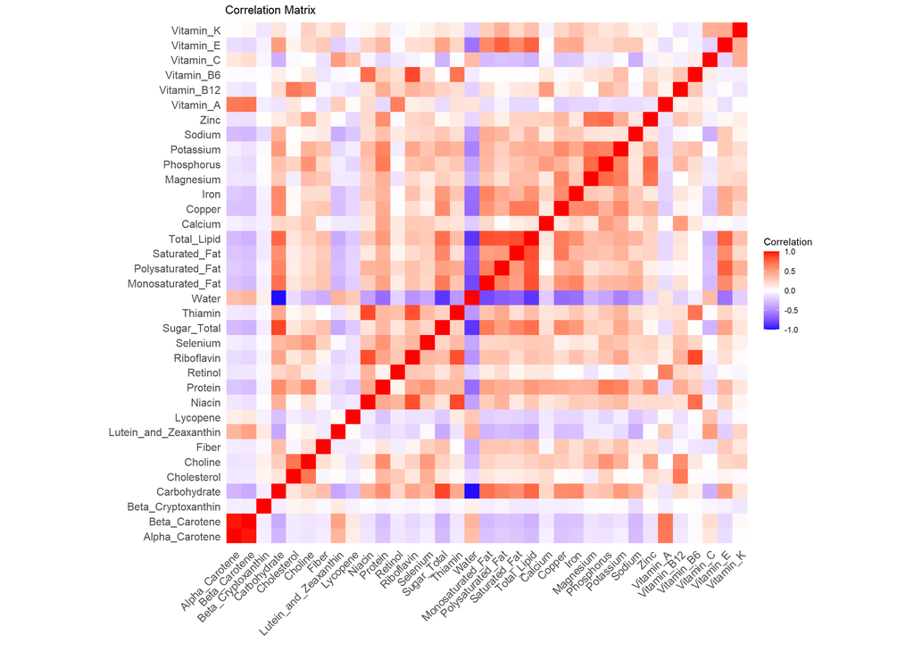

```r
cor_matrix_melt <- cleaned_data %>%
  select_if(is.numeric) %>%
  as.matrix() %>%
  rcorr() %>%
  {
    cor_matr <- .$r
    melt(cor_matr)  # Плавим корреляционную матрицу для ggplot
  }

ggplot(cor_matrix_melt, aes(Var1, Var2, fill = value)) +
        geom_tile() +
        scale_fill_gradient2(low = "blue", high = "red", mid = "white",
                             midpoint = 0, limit = c(-1, 1), space = "Lab",
                             name = "Correlation") +
        theme_minimal() +
        theme(axis.text.x = element_text(angle = 45, vjust = 1,
                                         size = 12, hjust = 1),
              axis.text.y = element_text(size = 12)) +
        coord_fixed() +
        labs(title = "Correlation Matrix", x = "", y = "")
```

Корреляционные матрицы помогают быстро визуализировать и оценить связи между переменными в наборе данных. Это может быть полезно при построении статистических моделей (например, регрессионных). Сильная корреляция между независимыми переменными может указывать на мультиколлинеарность, что повлияет на результаты модели.

Плюсы: 1. Корреляционные анализы проще и быстрее в выполнении, чем более сложные методы анализа, такие как регрессия или анализ вариации. 2.Результаты легко интерпретировать.

Минусы: 1. Невозможно установить причинно-следственные связи между переменными. 2. Корреляционные коэффициенты могут быть сильно искажены выбросами в данных.

## Моделирование

1. Постройте регрессионную модель для переменной **Category**. Опишите процесс построения

Построим барплот

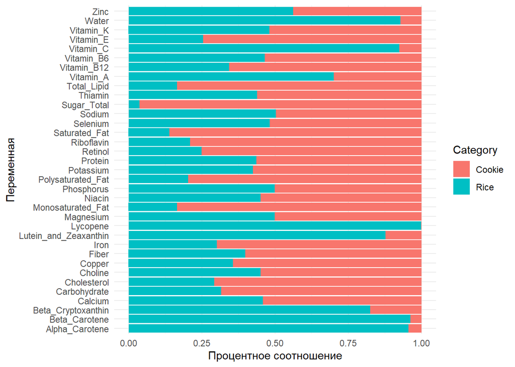

```r
cleaned_data <- cleaned_data %>%
  select(-Description, -Nutrient_Data_Bank_Number)


cleaned_data %>%
  pivot_longer(cols = where(is.numeric),
               names_to = "variable",
               values_to = "value") %>%
  ggplot(aes(x = variable, y = value, fill = Category)) +
  geom_bar(stat = "identity", position = "fill") +
  labs(x = "Переменная", y = "Процентное соотношение") +
  theme_minimal() +
  coord_flip()
```

**Разделим данные на тренировочную и тестовую выборки**

```r
set.seed(123)
split <- initial_split(cleaned_data, prop = 0.8, strata = Category)

train_data <- split %>%
  training()

test_data <- split %>%
  testing()
```

**Обучаем модель**

```r
model <- logistic_reg(mixture = double(1), penalty = double(1)) %>%
  set_engine("glmnet") %>%
  set_mode("classification") %>%
  fit(Category ~ ., data = train_data)

# Результаты модели
tidy(model)
```

| term | estimate | penalty |
| --- | --- | --- |
| (Intercept) | 4.6816567987 | 0 |
| Alpha_Carotene | 0.0005160385 | 0 |
| Beta_Carotene | 0.0003030826 | 0 |
| Beta_Cryptoxanthin | 0.0113412247 | 0 |
| Carbohydrate | -0.0274958969 | 0 |
| Cholesterol | -0.0024453851 | 0 |
| Choline | -0.0114344930 | 0 |
| Fiber | -0.1322442039 | 0 |
| Lutein_and_Zeaxanthin | 0.0011940030 | 0 |
| Lycopene | 0.0005436233 | 0 |

[output cut: 26 more lines]

**Прогнозируем классы и вероятности**

```r
pred_class <- predict(model,
                      new_data = test_data,
                      type = "class")

pred_proba <- predict(model,
                      new_data = test_data,
                      type = "prob")

results <- test_data %>% # Объединяем в таблицу results
  select(Category) %>%
  bind_cols(pred_class, pred_proba)
```

**Оцениваем точность модели с помощью accuracy**

```r
accuracy(results, truth = Category, estimate = .pred_class)
```

| .metric | .estimator | .estimate |
| --- | --- | --- |
| accuracy | binary | 1 |

**Настраиваем гиперпараметры**

```r
# Определяем логистическую регрессию с настройкой гиперпараметров mixture и penalty
log_reg <- logistic_reg(mixture = tune(), penalty = tune(), engine = "glmnet")

# Создаем сетку для подбора гиперпараметров
grid <- grid_regular(mixture(), penalty(), levels = c(mixture = 4, penalty = 3))

# Создаем объект для хранения сведений о модели
log_reg_wf <- workflow() %>%
  add_model(log_reg) %>%
  add_formula(Category ~ .)

# Определяем метод перекрестной проверки на тренировочной выборке (5-кратная кросс-валидация)
folds <- vfold_cv(train_data, v = 5)

# Подбраем гиперпараметры
log_reg_tuned <- tune_grid(
  log_reg_wf,
  resamples = folds,
  grid = grid,
  control = control_grid(save_pred = TRUE)
)

# Выбираем лучшие гиперпараметры на основе AUC
select_best(log_reg_tuned, metric = "roc_auc")
```

| penalty | mixture | .config |
| --- | --- | --- |
| 1e-10 | 0 | Preprocessor1_Model01 |

**Обучаем модель на тренировочной выборке**

```r
log_reg_final <- logistic_reg(penalty = 0.0000000001, mixture = 0) %>%
  set_engine("glmnet") %>%
  set_mode("classification") %>%
  fit(Category ~., data = train_data)
```

**Оцениваем эффективность модели на тестовой выборке**

```r
pred_class <- predict(log_reg_final,
                      new_data = test_data,
                      type = "class")
results <- test_data %>%
  select(Category) %>%
  bind_cols(pred_class, pred_proba)

# Строим матрицу ошибок (confusion matrix) для оценки качества классификации
conf_mat(results, truth = Category,
         estimate = .pred_class)
```

```
##           Truth
## Prediction Cookie Rice
##     Cookie     20    0
##     Rice        0   29
```

**Создаем таблицу коэффициентов финальной модели, создаем график**

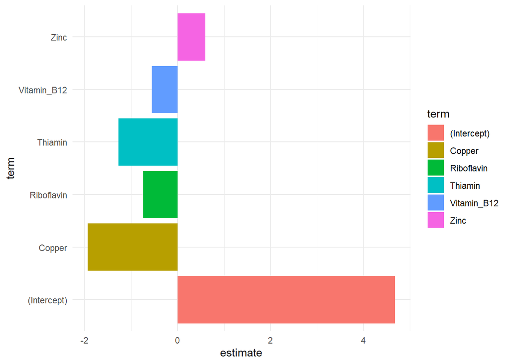

```r
coeff <- tidy(log_reg_final) %>%
  arrange(desc(abs(estimate))) %>%
  filter(abs(estimate) > 0.5) # абсолютное значение больше 0.5

ggplot(coeff, aes(x = term, y = estimate, fill = term)) +
  geom_col() +
  theme_minimal() +
  coord_flip()
```